# Modeling Growth and Disturbance with Dynamic Models

# Example with our population ODE

To have growth slow as carrying capcity is reached we can implement a logistic growth model

```r
source("../R/dexppopK.R")

dexppopK
```

```
## function (time, P, parms)
## {
##     dexpop = parms$r * P * (1 - P/parms$K)
##     return(list(dexpop))
## }
```

```r
# want to learn about sensitivity to growth rate (r) and carrying capacity
# set the number of parameters
np=100
K = rnorm(mean=300, sd=50, n=np)
r = rnorm(mean=0.01, sd=0.005, n=np)
X1 = cbind.data.frame(r=r, K=K)

# repeat to get our second set of samples
K = rnorm(mean=300, sd=50, n=np)
r = rnorm(mean=0.01, sd=0.005, n=np)
X2 = cbind.data.frame(r=r, K=K)

sens_P = sobolSalt(model = NULL,X1, X2, nboot = 300)

# our parameter sets are
head(sens_P$X)
```

```
##             [,1]     [,2]
## [1,] 0.017940677 337.0760
## [2,] 0.010413185 345.3397
## [3,] 0.006717361 257.4111
## [4,] 0.007114239 300.5623
## [5,] 0.007718271 309.1063
## [6,] 0.011526110 315.2159
```

```r
# lets add names
colnames(sens_P$X) = c("r","K")

# I may re-use this function so I saved it as a file
# maxyear doesn't make sense for a growth that slows gradually - so I'll use year when population doubles
source("../R/compute_pop_metrics.R")

Pinitial = 100

# I continually update the wrapper to I'll keep in inline
# you could make it a separate file as well
simtimes=seq(from=1, to=500, by=5)

p_wrapper = function(r,K, Pinitial, simtimes, func, metrics_func) {
    parms = list(r=r, K=K)
    result = ode(y=Pinitial, times=simtimes, func=func, parms=parms)
    colnames(result)=c("time","P")
  # get metrics
    metrics=as.data.frame(result) %>% metrics_func()
  return(metrics)
}

allresults = as.data.frame(sens_P$X) %>% pmap(p_wrapper, Pinitial=Pinitial, simtimes=simtimes, func=dexppopK, metrics_func=compute_pop_metrics)
```

[output not shown]

[output cut: 76 more lines]

[output not shown]

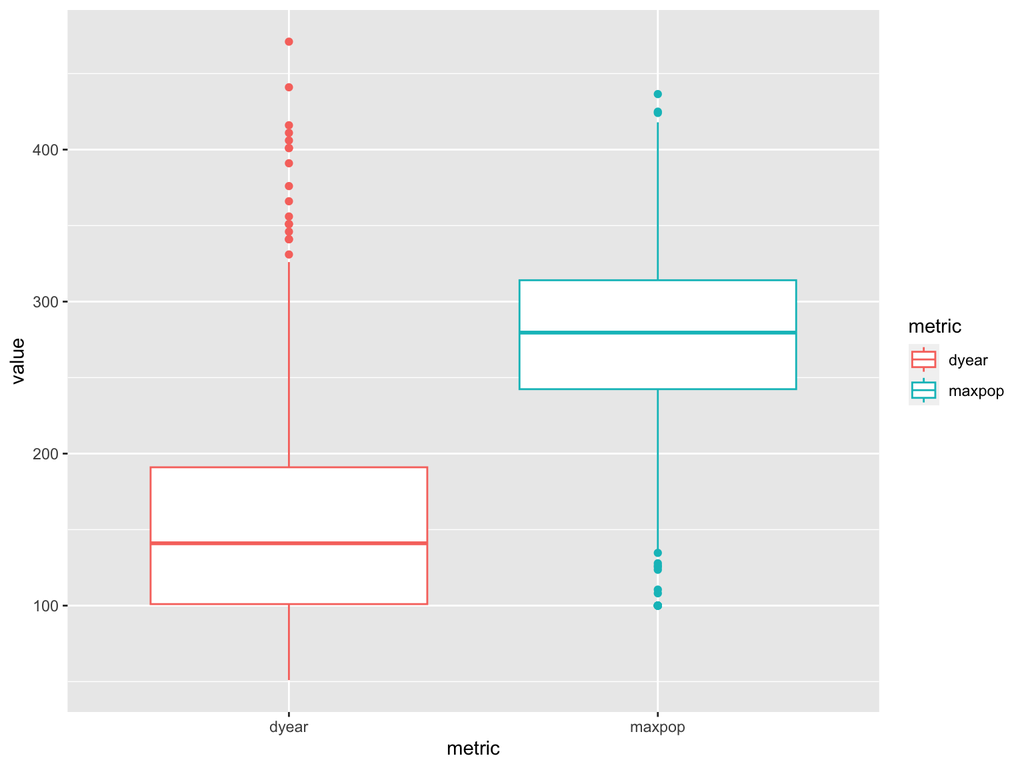

```r
# extract out results from pmap into a data frame
allres = allresults %>% map_dfr(`[`,c("maxpop","dyear"))


# create boxplots
tmp = allres %>% gather(key="metric", value="value")
ggplot(tmp, aes(metric, value, col=metric))+geom_boxplot()
```

```r
# compute sobol indicies (separately for the two different outputs)
sens_P_maxpop = sensitivity::tell(sens_P,allres$maxpop)

# first-order indices (main effect without co-variance)
sens_P_maxpop$S
```

```
##     original         bias std. error min. c.i. max. c.i.
## X1 0.3940871 -0.005211013 0.12112459 0.2044252 0.7006088
## X2 0.5466580  0.005722327 0.09468478 0.3504139 0.7298892
```

```r
# total sensitivity index -note that this partitions the output variance - so values sum to 1
sens_P_maxpop$T
```

```
##     original         bias std. error min. c.i. max. c.i.
## X1 0.5212469 -0.002623602  0.1072712 0.3101237 0.7576393
## X2 0.4687677  0.014595386  0.1009788 0.2378099 0.6354469
```

```r
# create another one for max year
sens_P_dyear = sensitivity::tell(sens_P,allres$dyear)
```

```
## Error in statistic(data, original, ...): NA/NaN/Inf in foreign function call (arg 1)
```

```r
# first-order indices (main effect without co-variance)

#notice that this fails because of NAs - scenarios where population does not double
summary(allres$dyear)
```

```
##    Min. 1st Qu.  Median    Mean 3rd Qu.    Max.    NA's
##      51     101     141     159     191     471      44
```

```r
# clean up option - not ideal but will work - set double year to max simtimes
allres$dyear_clean = ifelse(is.na(allres$dyear), max(simtimes), allres$dyear)
sens_P_dyear = sensitivity::tell(sens_P,allres$dyear_clean)
sens_P_dyear$S
```

```
##     original         bias std. error  min. c.i. max. c.i.
## X1 0.7278015  0.002682160 0.08367112 0.58196047 0.9115715
## X2 0.2866466 -0.004293799 0.10666217 0.08736333 0.5006294
```

```r
# total sensitivity index -note that this partitions the output variance - so values sum to 1
sens_P_dyear$T
```

```
##     original         bias std. error min. c.i. max. c.i.
## X1 0.8026902  0.003644102 0.09961321 0.5961516 0.9991784
## X2 0.1979899 -0.001690069 0.06494515 0.0503798 0.3012845
```

# Ways to use dynamic models

Goal: To provide insight into environmental systems, and how they respond to intervention/disturbance/change

- sensitivity analysis of output (output generated by solving differential equation to see system evolution in time or space)
  - output response to variation in inputs/parameters
  - quantifying how summary measures respond to variation in inputs/parameters
- examine derivative at different values (simpler, not solving required but just tells you how system will change given a particular state)
  - how does stability vary with inputs/parameters

# Another Application

Modeling carbon growth in a forest

r is growth rate K is maximum carbon capacity of the forest

We can actually re-use our model - if we assume forest growth follows a logistic growth curve

```r
source("../R/dexppopK.R")

dexppopK
```

```
## function (time, P, parms)
## {
##     dexpop = parms$r * P * (1 - P/parms$K)
##     return(list(dexpop))
## }
```

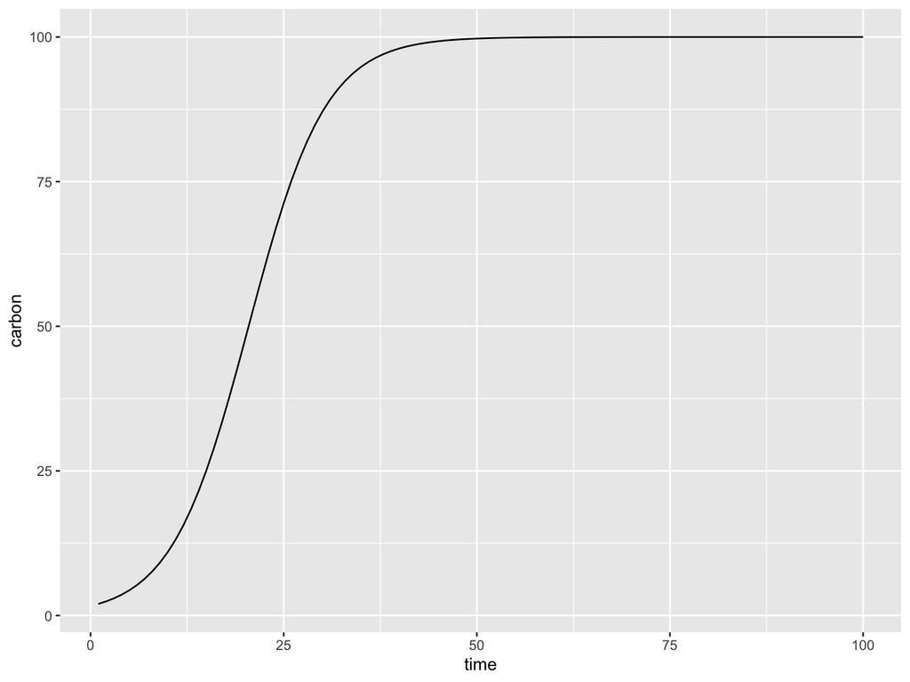

```r
# set parameters
forestparms = list(K=100,r=0.2)

# create a time sequence
tm = seq(from=1,to=100)

# start a small forest
postfire_initial_carbon = 2

# watch it grow
forest = ode(y=postfire_initial_carbon, times=tm, dexppopK, parms=forestparms)

colnames(forest)=c("time","carbon")
ggplot(as.data.frame(forest),aes(time, carbon) )+geom_line()
```

# Disturbance

What would our model look like if we harvest the forest on a regular basis

2 options

- a fixed harvest every year
- proportional harvest (% of current stock)

Lets start with an annual proportional harvest

(note we could make this really simple and just reduce the growth rate - but sometimes helpful to have both parameters as “options”)

```r
# fixed amount per year
source("../R/dharvest.R")
dharvest
```

```
## function (Time, P, parms)
## {
##     dP = parms$r * P * (1 - P/parms$K) - parms$harv * P
##     return(list(dP))
## }
```

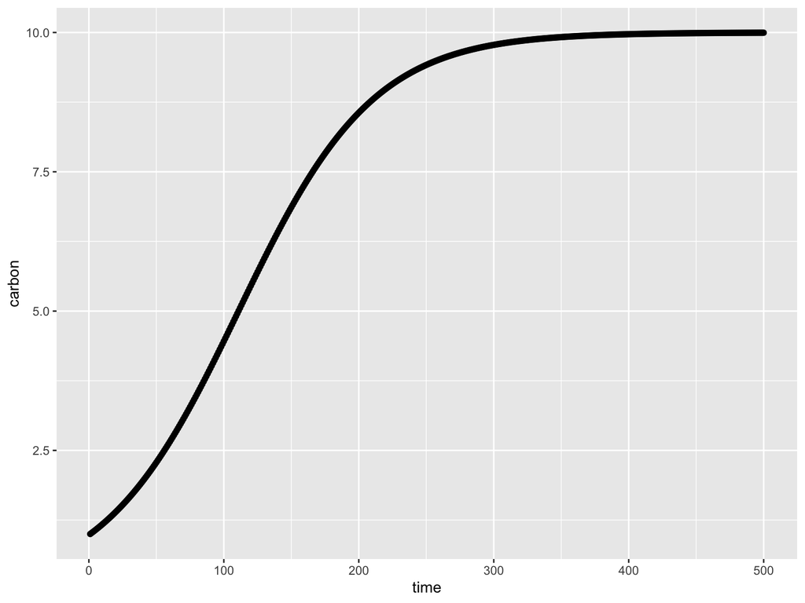

```r
# try it out
tm = seq(from=1, to=500)
Pinitial = 1
gps = list(harv=0.18, K=100, r=0.2)
res = ode(Pinitial,tm, dharvest, gps)
colnames(res)=c("time","carbon")

ggplot(as.data.frame(res), aes(time, carbon))+geom_point()
```

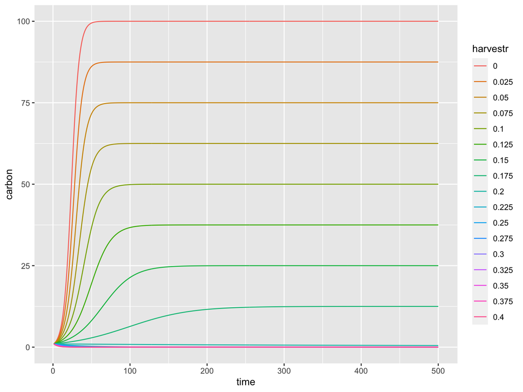

```r
# what if we harvest a a much greater rates

# lets vary the harvest rates from 0.0 to 0.4
harvestr = seq(from=0.0, to=0.4, by=0.025)

# save all of the trajectories


# use a wrapper function to just return the carbon trajectories
getcarbon = function(Pinitial, tm, harv, K, r, hfunc) {
  gps = list(harv=harv, K=K, r=r)
  res = ode(Pinitial,tm, hfunc, gps)
  colnames(res)=c("time","carbon")
  res=as.data.frame(res)
  return(carbon=res$carbon)
}

# apply this function to all harvest values
res = harvestr %>% map_dfc(~getcarbon( Pinitial=Pinitial, tm=tm, K=100, r=0.2, hfun=dharvest, harv=.x))
# rows are time, columns are carbon for each harvest scenario
colnames(res)=harvestr
res=as.data.frame(res)
res$time=tm
# put in to a form where we can plot
resl = gather(res, key="harvestr",value="carbon", -time)
ggplot(resl,aes(time, carbon, col=harvestr))+geom_line()
```

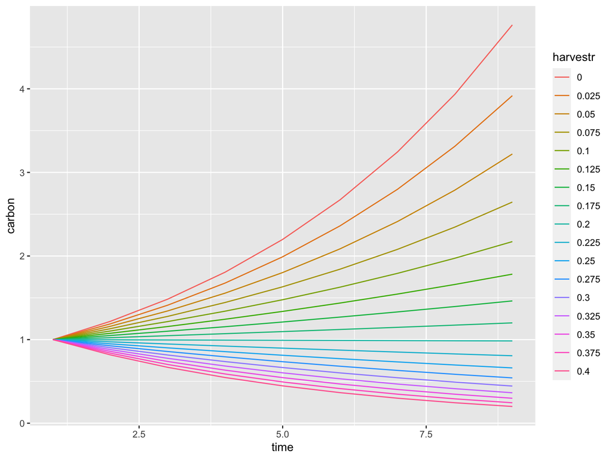

```r
# notice that stable forest value changes with harvest rates

# notes that some forests are not stable - (or stablity is zero)

# see this at the beginning - plot the first 10 years
ggplot(subset(resl, time < 10),aes(time, carbon, col=harvestr))+geom_line()
```

Try different harvest rates…notice how carbon growth changes…what does stability mean - can you find parameter sets that lead to a stable non-zero forest

We could do some sensitivity analysis to see how harvest rate, and growth rate interact to control where the forest ends up after 10 years and 50 years (short and long planning horizons)